# Parlamentares no Twitter: Popularidade e Engajamento

Matheus Alves dos Santos

22 de abril de 2019

Na maioria dos países democráticos, os parlamentares costumam adotar perfis em redes sociais como canais de comunicação não-oficiais, através dos quais podem não somente divulgar sua atuação política, mas também comentar assuntos cotidianos e entrar em contato direto da população em geral.

O Twitter tem atraído bastante a atenção dos brasileiros nos últimos meses e, muitas vezes, isso não se deve às suas funcionalidades, mas às polêmicas geradas a partir de postagens de figuras políticas do país. Nesse sentido, decidiu-se explorar os dados de nossos parlamentares *twitteiros* na tentativa de compreender melhor como se dá a atuação do Congresso Nacional brasileiro nessa rede social.

## Preparação do Ambiente

Para as análises apresentadas a seguir, foram utilizadas as bibliotecas **tidyverse** e **ggplot2**. Já os dados utilizados estão estruturados da seguinte maneira:

```r
glimpse(atividade)
```

```
## Observations: 608
## Variables: 19
## $ id_parlamentar        <chr> "204554", "204521", "204379", "204560", ...
## $ casa                  <chr> "câmara", "câmara", "câmara", "câmara", ...
## $ nome_eleitoral        <chr> "ABÍLIO SANTANA", "ABOU ANNI", "ACÁCIO F...
## $ partido               <chr> "PR", "PSL", "PROS", "PSDB", "NOVO", "PP...
## $ UF                    <chr> "BA", "SP", "AP", "BA", "SP", "GO", "MG"...
## $ twitter               <chr> "AbilioSantana_", "abouannipv", "Favacho...
## $ seguidores            <dbl> NA, NA, NA, NA, 4652, NA, NA, NA, NA, NA...
## $ segue                 <dbl> NA, NA, NA, NA, 315, NA, NA, NA, NA, NA,...
## $ n_proprio             <dbl> 0, 0, 0, 0, 99, 0, 0, 0, 0, 0, 0, 0, NA,...
## $ n_retweet             <dbl> 0, 0, 0, 0, 9, 0, 0, 0, 0, 0, 0, 0, NA, ...
## $ engaj_total           <dbl> 0, 0, 0, 0, 7090, 0, 0, 0, 0, 0, 0, 0, N...
## $ engaj_total_proprio   <dbl> 0, 0, 0, 0, 6701, 0, 0, 0, 0, 0, 0, 0, N...
## $ engaj_total_retweet   <dbl> 0, 0, 0, 0, 389, 0, 0, 0, 0, 0, 0, 0, NA...
## $ engaj_mediano         <dbl> 0.0, 0.0, 0.0, 0.0, 26.5, 0.0, 0.0, 0.0,...
## $ engaj_mediano_proprio <dbl> 0.0, 0.0, 0.0, 0.0, 22.5, 0.0, 0.0, 0.0,...
## $ engaj_mediano_retweet <dbl> 0.0, 0.0, 0.0, 0.0, 0.0, 0.0, 0.0, 0.0, ...
## $ engaj_max             <dbl> 0, 0, 0, 0, 1031, 0, 0, 0, 0, 0, 0, 0, N...
## $ engaj_max_proprio     <dbl> 0, 0, 0, 0, 1031, 0, 0, 0, 0, 0, 0, 0, N...
## $ engaj_max_retweet     <dbl> 0, 0, 0, 0, 99, 0, 0, 0, 0, 0, 0, 0, NA,...
```

## Análises

### 1 — Produzir conteúdo é o suficiente para ganhar seguidores?

Esse é um questionamento que costuma rodear as figuras públicas e, desta forma, torna-se pertinente na análise do comportamento de nossos parlamentares no *Twitter*. Os dados utilizados podem não ser suficientes para oferecer uma resposta final para essa pergunta, mas são muito úteis para buscar indícios de relação entre a quantidade de conteúdo produzido e o número de seguidores de cada parlamentar.

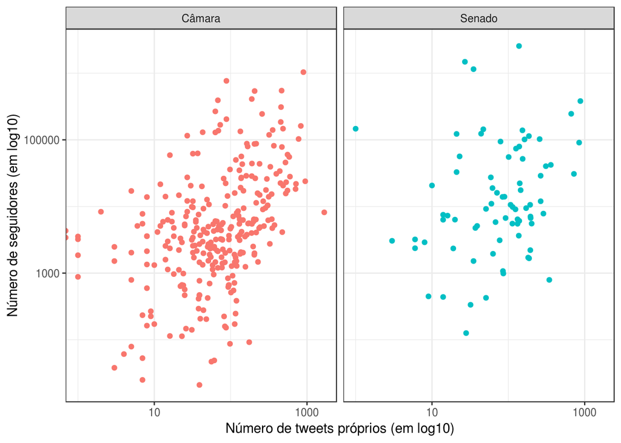

```r
parlamentares_com_tt <- atividade %>% filter(!is.na(twitter))
parlamentares_com_tt <- parlamentares_com_tt %>% mutate(casa = if_else(casa == 'senado', 'Senado', 'Câmara'))

parlamentares_com_tt %>%
  ggplot(aes(x = n_proprio, y = seguidores, color = casa)) +
  geom_point(show.legend = FALSE) +
  labs(x = "Número de tweets próprios (em log10)", y = "Número de seguidores (em log10)") +
  scale_x_log10() +
  scale_y_log10() +
  facet_wrap(~ casa)
```

```r
parlamentares_com_tt %>%
  filter(!is.na(n_proprio) & !is.na(seguidores)) %>%
  group_by(casa) %>%
    summarise(Pearson = cor(n_proprio, seguidores, method = "pearson"),
              Spearman = cor(n_proprio, seguidores, method = "spearman"),
              Kendall = cor(n_proprio, seguidores, method = "kendall"))
```

```
## # A tibble: 2 x 4
##   casa   Pearson Spearman Kendall
##   <chr>    <dbl>    <dbl>   <dbl>
## 1 Câmara  0.292     0.461   0.312
## 2 Senado  0.0315    0.255   0.177
```

Considerando as naturais diferenças entre deputados e senadores, optou-se por tratar os dados separadamente tanto para as visualizações quanto para o cálculo dos coeficientes de correlação. Além disso, para obter uma visualização mais adequada, adotou-se escalas logarítmicas (log10) tanto para o número de tweets próprios quanto para o número de seguidores.

A partir do *scatterplot* acima, percebe-se que, tanto para a Câmara quanto para o Senado, o número de seguidores e de *tweets* próprios são grandezas positivamente relacionadas, porém de maneira bastante fraca. Dessa forma, não é possível identificar um formato claro dessa relação, tampouco pontos extremos já que os pontos estão tão dispersos. Os coeficientes de correlação calculados usando os métodos de Pearson, Spearman e Kendall corroboram com essas impressões, mas também explicitam que a relação é especialmente fraca quando se considera os senadores.

### 2 — Os parlamentares mais *twitteiros* são aqueles que geram mais engajamento?

Guiando-se pelo senso comum, a existência de uma relação entre a quantidade de conteúdo produzido e o engajamento do público faz bastante sentido. Desta forma, decidiu-se investigar essas duas variáveis.

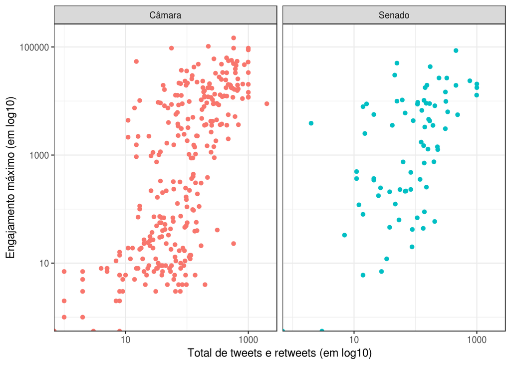

```r
parlamentares_com_tt <- parlamentares_com_tt %>% mutate(total_tweets = n_proprio + n_retweet)

parlamentares_com_tt %>%
  ggplot(aes(x = total_tweets, y = engaj_max, color = casa)) +
  geom_point(show.legend = FALSE) +
  labs(x = "Total de tweets e retweets (em log10)", y = "Engajamento máximo (em log10)") +
  scale_x_log10() +
  scale_y_log10() +
  facet_wrap(~ casa)
```

```r
parlamentares_com_tt %>%
  filter(!is.na(n_proprio) & !is.na(seguidores)) %>%
  group_by(casa) %>%
    summarise(Pearson = cor(total_tweets, engaj_max, method = "pearson"),
              Spearman = cor(total_tweets, engaj_max, method = "spearman"),
              Kendall = cor(total_tweets, engaj_max, method = "kendall"))
```

```
## # A tibble: 2 x 4
##   casa   Pearson Spearman Kendall
##   <chr>    <dbl>    <dbl>   <dbl>
## 1 Câmara   0.481    0.694   0.508
## 2 Senado   0.375    0.527   0.371
```

Mais uma vez, considerando as diferenças entre deputados e senadores, os dados foram separados de acordo com a casa a que os parlamentares pertencem. Objetivando uma visualização mais adequada ao leitor, adotou-se novamente escalas logarítmicas (log10) para as duas variáveis analisadas.

O *scatterplot* mais uma vez revelou que as variáveis estão relacionadas positivamente, porém, dessa vez também é possível perceber que os dados dos deputados descrevem uma função de natureza exponencial quando observados em escalas logarítmicas. A relação existente entre o engajamento máximo e o total de *tweets* e *retweets* também parece ser mais forte do que a relação avaliada anteriormente.

Em relação aos pontos extremos, é possível perceber que o senador **Cid Gomes** destoa bastante da tendência observada, atingindo um engajamento máximo acima de 1000 ainda que seja tão pouco ativo no Twitter. Por fim, os valores obtidos para os coeficientes de correlação calculados usando os métodos de Pearson, Spearman e Kendall corroboram com a percepção da existência de uma relação positiva e de força moderada entre as variáveis analisadas.